# Supervised Learning Project - Mohit Bansal

### Part -A

• DOMAIN: Medical

• CONTEXT: Medical research university X is undergoing a deep research on patients with certain conditions. University has an internal AI team. Due to confidentiality the patient’s details and the conditions are masked by the client by providing different datasets to the AI team for developing a AIML model which can predict the condition of the patient depending on the received test results.

• DATA DESCRIPTION: The data consists of biomechanics features of the patients according to their current conditions. Each patient is represented in the data set by six biomechanics attributes derived from the shape and orientation of the condition to their body part.

• PROJECT OBJECTIVE: To Demonstrate the ability to fetch, process and leverage data to generate useful predictions by training Supervised Learning algorithms.

#### 1 Data Understanding

##### 1.A Read all the 3 CSV files as DataFrame and store them into 3 separate variables.

```python
import pandas as pd
import seaborn as sns
import numpy as np
import matplotlib.pyplot as plt
%matplotlib inline
```

```python
type_h = pd.read_csv("Type_H.csv")
type_s = pd.read_csv("Type_S.csv")
type_normal = pd.read_csv("Normal.csv")
```

```python
# Reading Type_H Dataset
type_h.head(5)
```

|  | P_incidence | P_tilt | L_angle | S_slope | P_radius | S_Degree | Class |
| --- | --- | --- | --- | --- | --- | --- | --- |
| 0 | 63.027818 | 22.552586 | 39.609117 | 40.475232 | 98.672917 | -0.254400 | Type_H |
| 1 | 39.056951 | 10.060991 | 25.015378 | 28.995960 | 114.405425 | 4.564259 | Type_H |
| 2 | 68.832021 | 22.218482 | 50.092194 | 46.613539 | 105.985135 | -3.530317 | Type_H |
| 3 | 69.297008 | 24.652878 | 44.311238 | 44.644130 | 101.868495 | 11.211523 | Type_H |
| 4 | 49.712859 | 9.652075 | 28.317406 | 40.060784 | 108.168725 | 7.918501 | Type_H |

```python
# Reading Type_S Dataset
type_s.head(5)
```

|  | P_incidence | P_tilt | L_angle | S_slope | P_radius | S_Degree | Class |
| --- | --- | --- | --- | --- | --- | --- | --- |
| 0 | 74.377678 | 32.053104 | 78.772013 | 42.324573 | 143.560690 | 56.125906 | Type_S |
| 1 | 89.680567 | 32.704435 | 83.130732 | 56.976132 | 129.955476 | 92.027277 | Type_S |
| 2 | 44.529051 | 9.433234 | 52.000000 | 35.095817 | 134.711772 | 29.106575 | Type_S |
| 3 | 77.690577 | 21.380645 | 64.429442 | 56.309932 | 114.818751 | 26.931841 | Type_S |
| 4 | 76.147212 | 21.936186 | 82.961502 | 54.211027 | 123.932010 | 10.431972 | Type_S |

```python
# Reading Type Normal Dataset
type_normal.head(5)
```

|  | P_incidence | P_tilt | L_angle | S_slope | P_radius | S_Degree | Class |
| --- | --- | --- | --- | --- | --- | --- | --- |
| 0 | 38.505273 | 16.964297 | 35.112814 | 21.540976 | 127.632875 | 7.986683 | Normal |
| 1 | 54.920858 | 18.968430 | 51.601455 | 35.952428 | 125.846646 | 2.001642 | Normal |
| 2 | 44.362490 | 8.945435 | 46.902096 | 35.417055 | 129.220682 | 4.994195 | Normal |
| 3 | 48.318931 | 17.452121 | 48.000000 | 30.866809 | 128.980308 | -0.910941 | Normal |
| 4 | 45.701789 | 10.659859 | 42.577846 | 35.041929 | 130.178314 | -3.388910 | Normal |

##### 1.B Print 'Shape' and 'Columns' of each Dataframe

```python
# Print shape of Type_H Dataset
type_h.shape
```

```
(60, 7)
```

Shape of Type_H Dataset is 60 rows * 7 columns

```python
# Print Type_H Dataset Columns
type_h.columns
```

```
Index(['P_incidence', 'P_tilt', 'L_angle', 'S_slope', 'P_radius', 'S_Degree',
       'Class'],
      dtype='object')
```

```python
# Print shape of Type_S Dataset
type_s.shape
```

```
(150, 7)
```

Shape of Type_S Dataset is 150 rows * 7 columns

```python
# Print Type_S Dataset Columns
type_s.columns
```

```
Index(['P_incidence', 'P_tilt', 'L_angle', 'S_slope', 'P_radius', 'S_Degree',
       'Class'],
      dtype='object')
```

```python
# Print Type_Normal Dataset Shape
type_normal.shape
```

```
(100, 7)
```

Shape of Type_Normal Dataset is 100 rows * 7 columns

```python
# Print Type Normal Dataset Columns
type_normal.columns
```

```
Index(['P_incidence', 'P_tilt', 'L_angle', 'S_slope', 'P_radius', 'S_Degree',
       'Class'],
      dtype='object')
```

##### 1.C Compare Column names of all the 3 DataFrames and clearly write observations.

All the 3 datasets contain the identical number and types of Columns

##### 1.D Print DataTypes of all the 3 DataFrames.

```python
# Print Type_H Dataset datatypes
type_h.dtypes
```

```
P_incidence    float64
P_tilt         float64
L_angle        float64
S_slope        float64
P_radius       float64
S_Degree       float64
Class           object
dtype: object
```

```python
# Print Type_S Dataset datatypes
type_s.dtypes
```

```
P_incidence    float64
P_tilt         float64
L_angle        float64
S_slope        float64
P_radius       float64
S_Degree       float64
Class           object
dtype: object
```

```python
# Print Type_Normal Dataset datatypes
type_normal.dtypes
```

```
P_incidence    float64
P_tilt         float64
L_angle        float64
S_slope        float64
P_radius       float64
S_Degree       float64
Class           object
dtype: object
```

###### 1.E Observe and share variation in ‘Class’ feature of all the 3 DataFrames

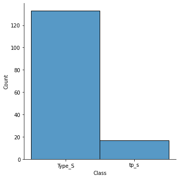

```python
# Variation in Class column of Type_S Dataset
sns.displot(type_s.Class)
```

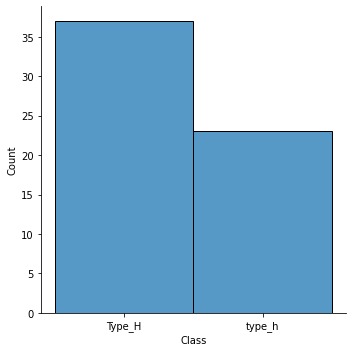

```python
# Variation in Class column of Type_H Dataset
sns.displot(type_h.Class)
```

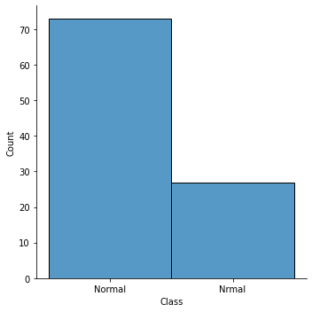

```python
# Variation in Class column of Type_Normal Dataset
sns.displot(type_normal.Class)
```

#### 2. Data Preparation and Exploration

##### 2.1 Unify all the variations in ‘Class’ feature for all the 3 DataFrames.

##### 2.2. Combine all the 3 Dataframes

```python
# Combine all 3 dataframes
df = type_h.append([type_s, type_normal])
```

```python
df.head(5)
```

|  | P_incidence | P_tilt | L_angle | S_slope | P_radius | S_Degree | Class |
| --- | --- | --- | --- | --- | --- | --- | --- |
| 0 | 63.027818 | 22.552586 | 39.609117 | 40.475232 | 98.672917 | -0.254400 | Type_H |
| 1 | 39.056951 | 10.060991 | 25.015378 | 28.995960 | 114.405425 | 4.564259 | Type_H |
| 2 | 68.832021 | 22.218482 | 50.092194 | 46.613539 | 105.985135 | -3.530317 | Type_H |
| 3 | 69.297008 | 24.652878 | 44.311238 | 44.644130 | 101.868495 | 11.211523 | Type_H |
| 4 | 49.712859 | 9.652075 | 28.317406 | 40.060784 | 108.168725 | 7.918501 | Type_H |

```python
df.shape
```

```
(310, 7)
```

```python
df.loc[df['Class']=='tp_s', 'Class'] = 'Type_S'
df.loc[df['Class']=='type_h', 'Class'] = 'Type_H'
df.loc[df['Class']=='Nrmal', 'Class']= 'Normal'
```

```python
df.Class.unique()
```

```
array(['Type_H', 'Type_S', 'Normal'], dtype=object)
```

##### 2.3 Print 5 random samples of this DataFrame

```python
df.sample(5)
```

|  | P_incidence | P_tilt | L_angle | S_slope | P_radius | S_Degree | Class |
| --- | --- | --- | --- | --- | --- | --- | --- |
| 37 | 74.720746 | 19.756942 | 82.735360 | 54.963804 | 109.356594 | 33.306067 | Type_S |
| 48 | 40.557357 | 17.977784 | 34.000000 | 22.579573 | 121.046246 | -1.537383 | Type_H |
| 48 | 63.172987 | 6.330911 | 63.000000 | 56.842076 | 110.644021 | 42.608076 | Type_S |
| 50 | 55.285852 | 20.440118 | 34.000000 | 34.845733 | 115.877017 | 3.558372 | Type_H |
| 75 | 67.804694 | 16.550662 | 43.256802 | 51.254033 | 119.685645 | 4.867540 | Normal |

##### 2.4 Print Feature-wise percentage of Null values.

```python
df.isnull().sum()
```

```
P_incidence    0
P_tilt         0
L_angle        0
S_slope        0
P_radius       0
S_Degree       0
Class          0
dtype: int64
```

```python
df.isna().sum()
```

```
P_incidence    0
P_tilt         0
L_angle        0
S_slope        0
P_radius       0
S_Degree       0
Class          0
dtype: int64
```

##### 2.5 Check 5-point summary of the new DataFrame.

```python
df.describe()
```

|  | P_incidence | P_tilt | L_angle | S_slope | P_radius | S_Degree |
| --- | --- | --- | --- | --- | --- | --- |
| count | 310.000000 | 310.000000 | 310.000000 | 310.000000 | 310.000000 | 310.000000 |
| mean | 60.496653 | 17.542822 | 51.930930 | 42.953831 | 117.920655 | 26.296694 |
| std | 17.236520 | 10.008330 | 18.554064 | 13.423102 | 13.317377 | 37.559027 |
| min | 26.147921 | -6.554948 | 14.000000 | 13.366931 | 70.082575 | -11.058179 |
| 25% | 46.430294 | 10.667069 | 37.000000 | 33.347122 | 110.709196 | 1.603727 |
| 50% | 58.691038 | 16.357689 | 49.562398 | 42.404912 | 118.268178 | 11.767934 |
| 75% | 72.877696 | 22.120395 | 63.000000 | 52.695888 | 125.467674 | 41.287352 |
| max | 129.834041 | 49.431864 | 125.742385 | 121.429566 | 163.071041 | 418.543082 |

#### 3 Data Analysis

##### 3.1 Visualize a heatmap to understand correlation between all features

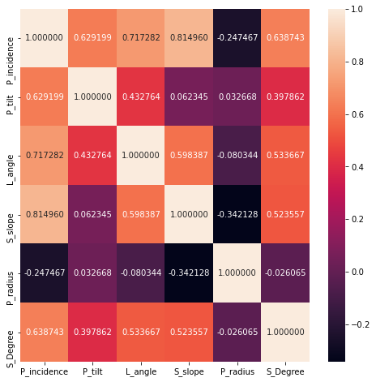

```python
plt.figure(figsize=(8,8))
sns.heatmap(df.corr(), annot=True, fmt='f')
plt.show()
```

#### 3.2 Share insights on correlation.

**It seems P_Incidence has a positive corelatio with all the features except P_radius**

**It seems P_radius has no or lower corelation to most other features**

##### 3.3 Visualize a pairplot with 3 classes distinguished by colors and share insights.

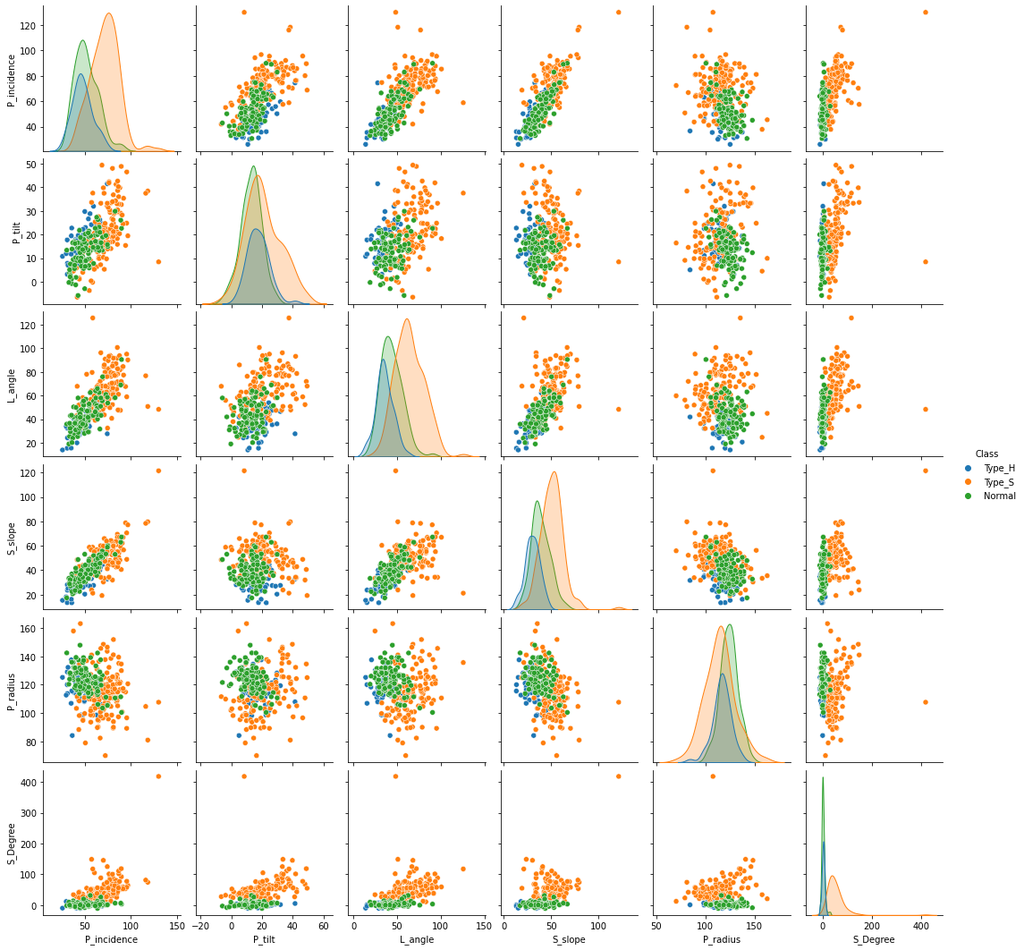

```python
sns.pairplot(df, hue='Class')
```

**It seems that class 'type_s' class frequency is higher than other two classes**

##### 3.4 Visualize a jointplot for ‘P_incidence’ and ‘S_slope’ and share insights

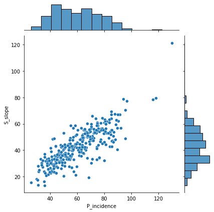

```python
sns.jointplot(data=df, x='P_incidence', y='S_slope')
```

**It seems there is a positive corelation between both S_slope & P_incidence features**

**P_incidence values are right skewed**

##### 3.5 Visualize a boxplot to check distribution of the features and share insights

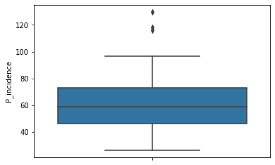

```python
# P_Incidence Feature distribution
sns.boxplot(data=df, y="P_incidence")
```

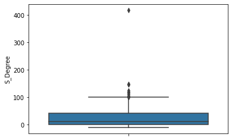

```python
# S_Degree Feature Distribution
sns.boxplot(data=df, y="S_Degree")
```

**Even S_Degree is highly right skewed with outliers**

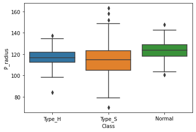

```python
# P_radius vs Class
sns.boxplot(data=df, y='P_radius', x='Class')
```

#### 4. Model Building

##### 4.1 Split Data into X, Y

```python
from sklearn.model_selection import train_test_split
from sklearn.preprocessing import LabelEncoder

df.Class.value_counts()
```

```
Type_S    150
Normal    100
Type_H     60
Name: Class, dtype: int64
```

```python
# Label Encode the Target Variable
labelEncoder = LabelEncoder()

df['Class']= labelEncoder.fit_transform(df['Class'])
df.Class.value_counts()
```

```
2    150
0    100
1     60
Name: Class, dtype: int64
```

Type_S = 2, Normal = 0, Type_H = 1

```python
df.describe()
```

|  | P_incidence | P_tilt | L_angle | S_slope | P_radius | S_Degree | Class |
| --- | --- | --- | --- | --- | --- | --- | --- |
| count | 310.000000 | 310.000000 | 310.000000 | 310.000000 | 310.000000 | 310.000000 | 310.000000 |
| mean | 60.496653 | 17.542822 | 51.930930 | 42.953831 | 117.920655 | 26.296694 | 1.161290 |
| std | 17.236520 | 10.008330 | 18.554064 | 13.423102 | 13.317377 | 37.559027 | 0.884852 |
| min | 26.147921 | -6.554948 | 14.000000 | 13.366931 | 70.082575 | -11.058179 | 0.000000 |
| 25% | 46.430294 | 10.667069 | 37.000000 | 33.347122 | 110.709196 | 1.603727 | 0.000000 |
| 50% | 58.691038 | 16.357689 | 49.562398 | 42.404912 | 118.268178 | 11.767934 | 1.000000 |
| 75% | 72.877696 | 22.120395 | 63.000000 | 52.695888 | 125.467674 | 41.287352 | 2.000000 |
| max | 129.834041 | 49.431864 | 125.742385 | 121.429566 | 163.071041 | 418.543082 | 2.000000 |

It seems we need to scale all the features

```python
# Test Train Split

X = df.drop(['Class'], axis=1)
X.head(5)
```

|  | P_incidence | P_tilt | L_angle | S_slope | P_radius | S_Degree |
| --- | --- | --- | --- | --- | --- | --- |
| 0 | 63.027818 | 22.552586 | 39.609117 | 40.475232 | 98.672917 | -0.254400 |
| 1 | 39.056951 | 10.060991 | 25.015378 | 28.995960 | 114.405425 | 4.564259 |
| 2 | 68.832021 | 22.218482 | 50.092194 | 46.613539 | 105.985135 | -3.530317 |
| 3 | 69.297008 | 24.652878 | 44.311238 | 44.644130 | 101.868495 | 11.211523 |
| 4 | 49.712859 | 9.652075 | 28.317406 | 40.060784 | 108.168725 | 7.918501 |

```python
# Lets Apply Standardization to all the dependent Variables
from sklearn.preprocessing import StandardScaler
standardScaler = StandardScaler()
X_scaled = standardScaler.fit_transform(X)
```

```python
X = pd.DataFrame(X_scaled, columns=X.columns)
X.head(5)
```

|  | P_incidence | P_tilt | L_angle | S_slope | P_radius | S_Degree |
| --- | --- | --- | --- | --- | --- | --- |
| 0 | 0.147086 | 0.501369 | -0.665177 | -0.184950 | -1.447647 | -0.708059 |
| 1 | -1.245864 | -0.748769 | -1.453001 | -1.041521 | -0.264385 | -0.579556 |
| 2 | 0.484370 | 0.467932 | -0.099262 | 0.273083 | -0.897686 | -0.795421 |
| 3 | 0.511390 | 0.711562 | -0.411339 | 0.126128 | -1.207303 | -0.402288 |
| 4 | -0.626648 | -0.789693 | -1.274745 | -0.215876 | -0.733455 | -0.490106 |

```python
y = df['Class']
y.head(5)
```

```
0    1
1    1
2    1
3    1
4    1
Name: Class, dtype: int32
```

##### 4.2 Split Data into 80, 20 Ratio

```python
 X_train, X_test, y_train, y_test = train_test_split(X, y, random_state=10, test_size=0.2)
```

##### 4.3 Train a Supervised Learning Classification base model using KNN classifier.

```python
from sklearn.neighbors import KNeighborsClassifier
from sklearn.metrics import accuracy_score, consensus_score, confusion_matrix
from sklearn.metrics import classification_report
```

```python
# Model Building
KNN = KNeighborsClassifier(n_neighbors= 5 ,metric = 'minkowski' )
```

```python
KNN.fit(X_train, y_train)
predicted_values = KNN.predict(X_test)
```

```python
print('Training Accuracy', KNN.score(X_train, y_train))
print('Test Accuracy', KNN.score(X_test, y_test))
```

```
Training Accuracy 0.8346774193548387
Test Accuracy 0.8064516129032258
```

```python
conf_metrix = confusion_matrix(y_test, predicted_values, labels=[0,1,2])
```

```python
conf_metrix
```

```
array([[14,  2,  2],
       [ 2, 10,  0],
       [ 1,  5, 26]], dtype=int64)
```

```python
conf_metrix_df = pd.DataFrame(conf_metrix, index=[i for i in ['Type_H', 'Normal', 'Type_S']], columns=[j for j in ['Type_H', 'Normal', 'Type_S']])
conf_metrix_df.head(5)
```

[output not shown]

[figure not shown]

```python
sns.heatmap(conf_metrix_df, annot=True)
```

##### 4.4 Print all the possible performance metrics for both train and test data

```python
print(classification_report(y_test, predicted_values))
```

```
              precision    recall  f1-score   support

           0       0.82      0.78      0.80        18
           1       0.59      0.83      0.69        12
           2       0.93      0.81      0.87        32

    accuracy                           0.81        62
   macro avg       0.78      0.81      0.79        62
weighted avg       0.83      0.81      0.81        62
```

#### 5. Performance Improvements

##### 5.1 Experiment with various parameters to improve performance of the base model

```python
# Lets check model performance for various values of K Neearest Neighbours

train_accuracies = []
test_accuracies = []

for i in range(2, 25):
    KNN = KNeighborsClassifier(n_neighbors=i)
    KNN.fit(X_train, y_train)
    train_accuracies.append(KNN.score(X_train, y_train))
    test_accuracies.append(KNN.score(X_test, y_test))
```

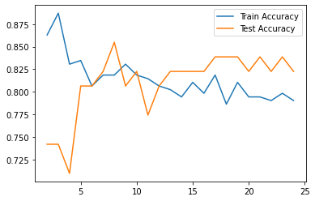

```python
plt.plot(range(2, 25), train_accuracies, label='Train Accuracy')
plt.plot(range(2, 25), test_accuracies,  label='Test Accuracy')
plt.legend()
plt.show()
```

**It seems Training Accuracy decreases with increase in value of Nearest Neighbours**

**It seems KNN model performs best for around 8 value of Nearest Neighbours**

##### 5.3 Clearly showcase improvement in performance achieved.

```python
# Lets check model performance for various values of K Neearest Neighbours

for i in [4,5,7,9,10,12,14,16]:
    KNN = KNeighborsClassifier(n_neighbors=i)
    KNN.fit(X_train, y_train)
    y_pred = KNN.predict(X_test)
    print('Train Accuracy for K== {} is {}'.format(i, KNN.score(X_train, y_train)))
    print('Test Accuracy for k== {} is {}'.format(i, KNN.score(X_test, y_test)))
    print("Classification Report: \n", classification_report(y_test, y_pred))
```

```
Train Accuracy for K== 4 is 0.8306451612903226
Test Accuracy for k== 4 is 0.7096774193548387
Classification Report:
               precision    recall  f1-score   support

           0       0.62      0.83      0.71        18
           1       0.38      0.42      0.40        12
           2       0.96      0.75      0.84        32

    accuracy                           0.71        62
   macro avg       0.66      0.67      0.65        62
weighted avg       0.75      0.71      0.72        62

Train Accuracy for K== 5 is 0.8346774193548387
Test Accuracy for k== 5 is 0.8064516129032258
Classification Report:
               precision    recall  f1-score   support

           0       0.82      0.78      0.80        18
           1       0.59      0.83      0.69        12
           2       0.93      0.81      0.87        32

    accuracy                           0.81        62
   macro avg       0.78      0.81      0.79        62
weighted avg       0.83      0.81      0.81        62

Train Accuracy for K== 7 is 0.8185483870967742
Test Accuracy for k== 7 is 0.8225806451612904
Classification Report:
               precision    recall  f1-score   support

           0       0.81      0.72      0.76        18
           1       0.62      0.83      0.71        12
           2       0.93      0.88      0.90        32

    accuracy                           0.82        62
   macro avg       0.79      0.81      0.79        62
weighted avg       0.84      0.82      0.83        62

Train Accuracy for K== 9 is 0.8306451612903226
```

[output cut: 48 more lines]

```
   macro avg       0.78      0.79      0.79        62
weighted avg       0.83      0.82      0.82        62

Train Accuracy for K== 16 is 0.7983870967741935
Test Accuracy for k== 16 is 0.8225806451612904
Classification Report:
               precision    recall  f1-score   support

           0       0.75      0.83      0.79        18
           1       0.67      0.67      0.67        12
           2       0.93      0.88      0.90        32

    accuracy                           0.82        62
   macro avg       0.78      0.79      0.79        62
weighted avg       0.83      0.82      0.82        62
```

##### 5.4 Clearly state which parameters contributed most to improve model performance

**There are only two possible HyperParameters for KNN Model, i.e Neighbour Count and Distance Metrics**

### Part B

DOMAIN: Banking, Marketing • CONTEXT: A bank X is on a massive digital transformation for all its departments. Bank has a growing customer base whee majority of them are liability customers (depositors) vs borrowers (asset customers). The bank is interested in expanding the borrowers base rapidly to bring in more business via loan interests. A campaign that the bank ran in last quarter showed an average single digit conversion rate. Digital transformation being the core strength of the business strategy, marketing department wants to devise effective campaigns with better target marketing to increase the conversion ratio to double digit with same budget as per last campaign. • DATA DICTIONARY:

1. Team: Team’s name
2. ID: Customer ID
3. Age: Customer’s approximate age.
4. CustomerSince: Customer of the bank since. [unit is masked]
5. HighestSpend: Customer’s highest spend so far in one transaction. [unit is masked]
6. ZipCode: Customer’s zip code.
7. HiddenScore: A score associated to the customer which is masked by the bank as an IP.
8. MonthlyAverageSpend: Customer’s monthly average spend so far. [unit is masked]
9. Level: A level associated to the customer which is masked by the bank as an IP.
10. Mortgage: Customer’s mortgage. [unit is masked]
11. Security: Customer’s security asset with the bank. [unit is masked]
12. FixedDepositAccount: Customer’s fixed deposit account with the bank. [unit is masked]
13. InternetBanking: if the customer uses internet banking.
14. CreditCard: if the customer uses bank’s credit card.
15. LoanOnCard: if the customer has a loan on credit card.

#### 1. Data Understanding and Preparation

##### 1A. Read both the Datasets ‘Data1’ and ‘Data 2’ as DataFrame and store them into two separate variables.

```python
data1 = pd.read_csv('Data1.csv')
```

```python
data1.head(5)
```

|  | ID | Age | CustomerSince | HighestSpend | ZipCode | HiddenScore | MonthlyAverageSpend | Level |
| --- | --- | --- | --- | --- | --- | --- | --- | --- |
| 0 | 1 | 25 | 1 | 49 | 91107 | 4 | 1.6 | 1 |
| 1 | 2 | 45 | 19 | 34 | 90089 | 3 | 1.5 | 1 |
| 2 | 3 | 39 | 15 | 11 | 94720 | 1 | 1.0 | 1 |
| 3 | 4 | 35 | 9 | 100 | 94112 | 1 | 2.7 | 2 |
| 4 | 5 | 35 | 8 | 45 | 91330 | 4 | 1.0 | 2 |

```python
data2 = pd.read_csv('Data2.csv')
data2.head(5)
```

|  | ID | Mortgage | Security | FixedDepositAccount | InternetBanking | CreditCard | LoanOnCard |
| --- | --- | --- | --- | --- | --- | --- | --- |
| 0 | 1 | 0 | 1 | 0 | 0 | 0 | NaN |
| 1 | 2 | 0 | 1 | 0 | 0 | 0 | NaN |
| 2 | 3 | 0 | 0 | 0 | 0 | 0 | NaN |
| 3 | 4 | 0 | 0 | 0 | 0 | 0 | NaN |
| 4 | 5 | 0 | 0 | 0 | 0 | 1 | NaN |

##### 1B. Print shape and Column Names and DataTypes of both the Dataframes

```python
data1.info()
```

```
<class 'pandas.core.frame.DataFrame'>
RangeIndex: 5000 entries, 0 to 4999
Data columns (total 8 columns):
 #   Column               Non-Null Count  Dtype
---  ------               --------------  -----
 0   ID                   5000 non-null   int64
 1   Age                  5000 non-null   int64
 2   CustomerSince        5000 non-null   int64
 3   HighestSpend         5000 non-null   int64
 4   ZipCode              5000 non-null   int64
 5   HiddenScore          5000 non-null   int64
 6   MonthlyAverageSpend  5000 non-null   float64
 7   Level                5000 non-null   int64
dtypes: float64(1), int64(7)
memory usage: 312.6 KB
```

```python
data1.shape
```

```
(5000, 8)
```

```python
data2.info()
```

```
<class 'pandas.core.frame.DataFrame'>
RangeIndex: 5000 entries, 0 to 4999
Data columns (total 7 columns):
 #   Column               Non-Null Count  Dtype
---  ------               --------------  -----
 0   ID                   5000 non-null   int64
 1   Mortgage             5000 non-null   int64
 2   Security             5000 non-null   int64
 3   FixedDepositAccount  5000 non-null   int64
 4   InternetBanking      5000 non-null   int64
 5   CreditCard           5000 non-null   int64
 6   LoanOnCard           4980 non-null   float64
dtypes: float64(1), int64(6)
memory usage: 273.6 KB
```

```python
data2.shape
```

```
(5000, 7)
```

##### 1C. Merge both the Dataframes on ‘ID’ feature to form a single DataFrame [

```python
final = pd.merge(data1, data2, on="ID")
```

```python
final.shape
```

```
(5000, 14)
```

```python
final.head(10)
```

|  | ID | Age | CustomerSince | HighestSpend | ZipCode | HiddenScore | MonthlyAverageSpend | Level | Mortgage | Security | FixedDepositAccount | InternetBanking | CreditCard | LoanOnCard |
| --- | --- | --- | --- | --- | --- | --- | --- | --- | --- | --- | --- | --- | --- | --- |
| 0 | 1 | 25 | 1 | 49 | 91107 | 4 | 1.6 | 1 | 0 | 1 | 0 | 0 | 0 | NaN |
| 1 | 2 | 45 | 19 | 34 | 90089 | 3 | 1.5 | 1 | 0 | 1 | 0 | 0 | 0 | NaN |
| 2 | 3 | 39 | 15 | 11 | 94720 | 1 | 1.0 | 1 | 0 | 0 | 0 | 0 | 0 | NaN |
| 3 | 4 | 35 | 9 | 100 | 94112 | 1 | 2.7 | 2 | 0 | 0 | 0 | 0 | 0 | NaN |
| 4 | 5 | 35 | 8 | 45 | 91330 | 4 | 1.0 | 2 | 0 | 0 | 0 | 0 | 1 | NaN |
| 5 | 6 | 37 | 13 | 29 | 92121 | 4 | 0.4 | 2 | 155 | 0 | 0 | 1 | 0 | NaN |
| 6 | 7 | 53 | 27 | 72 | 91711 | 2 | 1.5 | 2 | 0 | 0 | 0 | 1 | 0 | NaN |
| 7 | 8 | 50 | 24 | 22 | 93943 | 1 | 0.3 | 3 | 0 | 0 | 0 | 0 | 1 | NaN |
| 8 | 9 | 35 | 10 | 81 | 90089 | 3 | 0.6 | 2 | 104 | 0 | 0 | 1 | 0 | NaN |
| 9 | 10 | 34 | 9 | 180 | 93023 | 1 | 8.9 | 3 | 0 | 0 | 0 | 0 | 0 | 1.0 |

##### 1D. Change Datatype of below features to ‘Object’

```python
final.dtypes
```

```
ID                       int64
Age                      int64
CustomerSince            int64
HighestSpend             int64
ZipCode                  int64
HiddenScore              int64
MonthlyAverageSpend    float64
Level                    int64
Mortgage                 int64
Security                 int64
FixedDepositAccount      int64
InternetBanking          int64
CreditCard               int64
LoanOnCard             float64
dtype: object
```

```python
columns=['HiddenScore','Level','Security','FixedDepositAccount', 'InternetBanking', 'CreditCard', 'LoanOnCard']
for i in columns:
    final[i]=final[i].astype('category')
```

```python
final.dtypes
```

```
ID                        int64
Age                       int64
CustomerSince             int64
HighestSpend              int64
ZipCode                   int64
HiddenScore            category
MonthlyAverageSpend     float64
Level                  category
Mortgage                  int64
Security               category
FixedDepositAccount    category
InternetBanking        category
CreditCard             category
LoanOnCard             category
dtype: object
```

#### 2. Data Exploration and Analysis

##### 2.1 Visualize distribution of Target variable ‘LoanOnCard’ and clearly share insights

##### 2.2. Check the percentage of missing values and impute if required. [

```python
# Check for Missing Values
final.isnull().sum()
```

```
ID                      0
Age                     0
CustomerSince           0
HighestSpend            0
ZipCode                 0
HiddenScore             0
MonthlyAverageSpend     0
Level                   0
Mortgage                0
Security                0
FixedDepositAccount     0
InternetBanking         0
CreditCard              0
LoanOnCard             20
dtype: int64
```

```python
# Lets drop the na values, since thera are only 20 null rows
final.dropna(axis=0, inplace=True)
```

```python
final.isnull().sum()
```

```
ID                     0
Age                    0
CustomerSince          0
HighestSpend           0
ZipCode                0
HiddenScore            0
MonthlyAverageSpend    0
Level                  0
Mortgage               0
Security               0
FixedDepositAccount    0
InternetBanking        0
CreditCard             0
LoanOnCard             0
dtype: int64
```

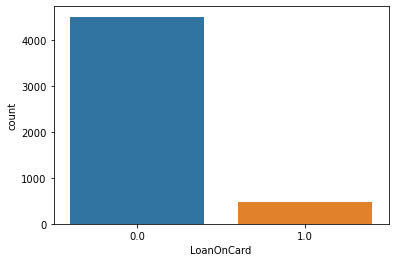

```python
sns.countplot(final["LoanOnCard"])
```

```python
final.LoanOnCard.value_counts()
```

```
0.0    4500
1.0     480
Name: LoanOnCard, dtype: int64
```

**Observation:- It seems around 90% of Bank Customers doesnt have any LoanOnCard**

##### 2.3 Check for unexpected values in each categorical variable and impute with best suitable value

```python
columns=['HiddenScore','Level','Security','FixedDepositAccount', 'InternetBanking', 'CreditCard', 'LoanOnCard']

final.HiddenScore.value_counts()
```

```
1    1466
2    1293
4    1215
3    1006
Name: HiddenScore, dtype: int64
```

```python
final.Level.value_counts()
```

```
1    2089
3    1496
2    1395
Name: Level, dtype: int64
```

```python
final.Security.value_counts()
```

```
0    4460
1     520
Name: Security, dtype: int64
```

```python
final.FixedDepositAccount.value_counts()
```

```
0    4678
1     302
Name: FixedDepositAccount, dtype: int64
```

```python
final.InternetBanking.value_counts()
```

```
1    2974
0    2006
Name: InternetBanking, dtype: int64
```

```python
final.CreditCard.value_counts()
```

```
0    3514
1    1466
Name: CreditCard, dtype: int64
```

```python
final.describe(include='all')
```

|  | ID | Age | CustomerSince | HighestSpend | ZipCode | HiddenScore | MonthlyAverageSpend | Level | Mortgage | Security | FixedDepositAccount | InternetBanking | CreditCard | LoanOnCard |
| --- | --- | --- | --- | --- | --- | --- | --- | --- | --- | --- | --- | --- | --- | --- |
| count | 4980.000000 | 4980.000000 | 4980.000000 | 4980.00000 | 4980.000000 | 4980.0 | 4980.000000 | 4980.0 | 4980.000000 | 4980.0 | 4980.0 | 4980.0 | 4980.0 | 4980.0 |
| unique | NaN | NaN | NaN | NaN | NaN | 4.0 | NaN | 3.0 | NaN | 2.0 | 2.0 | 2.0 | 2.0 | 2.0 |
| top | NaN | NaN | NaN | NaN | NaN | 1.0 | NaN | 1.0 | NaN | 0.0 | 0.0 | 1.0 | 0.0 | 0.0 |
| freq | NaN | NaN | NaN | NaN | NaN | 1466.0 | NaN | 2089.0 | NaN | 4460.0 | 4678.0 | 2974.0 | 3514.0 | 4500.0 |
| mean | 2510.345382 | 45.352610 | 20.117671 | 73.85241 | 93152.420482 | NaN | 1.939536 | NaN | 56.589759 | NaN | NaN | NaN | NaN | NaN |
| std | 1438.011129 | 11.464212 | 11.468716 | 46.07009 | 2123.660073 | NaN | 1.750006 | NaN | 101.836758 | NaN | NaN | NaN | NaN | NaN |
| min | 10.000000 | 23.000000 | -3.000000 | 8.00000 | 9307.000000 | NaN | 0.000000 | NaN | 0.000000 | NaN | NaN | NaN | NaN | NaN |
| 25% | 1265.750000 | 35.000000 | 10.000000 | 39.00000 | 91911.000000 | NaN | 0.700000 | NaN | 0.000000 | NaN | NaN | NaN | NaN | NaN |
| 50% | 2510.500000 | 45.000000 | 20.000000 | 64.00000 | 93407.000000 | NaN | 1.500000 | NaN | 0.000000 | NaN | NaN | NaN | NaN | NaN |
| 75% | 3755.250000 | 55.000000 | 30.000000 | 98.00000 | 94608.000000 | NaN | 2.525000 | NaN | 101.000000 | NaN | NaN | NaN | NaN | NaN |
| max | 5000.000000 | 67.000000 | 43.000000 | 224.00000 | 96651.000000 | NaN | 10.000000 | NaN | 635.000000 | NaN | NaN | NaN | NaN | NaN |

```python
#Lets drop 'ID' column as it doesnt adds value
final.drop(['ID'],axis=1, inplace=True)
```

```python
final.head(5)
```

|  | Age | CustomerSince | HighestSpend | ZipCode | HiddenScore | MonthlyAverageSpend | Level | Mortgage | Security | FixedDepositAccount | InternetBanking | CreditCard | LoanOnCard |
| --- | --- | --- | --- | --- | --- | --- | --- | --- | --- | --- | --- | --- | --- |
| 9 | 34 | 9 | 180 | 93023 | 1 | 8.9 | 3 | 0 | 0 | 0 | 0 | 0 | 1.0 |
| 10 | 65 | 39 | 105 | 94710 | 4 | 2.4 | 3 | 0 | 0 | 0 | 0 | 0 | 0.0 |
| 11 | 29 | 5 | 45 | 90277 | 3 | 0.1 | 2 | 0 | 0 | 0 | 1 | 0 | 0.0 |
| 12 | 48 | 23 | 114 | 93106 | 2 | 3.8 | 3 | 0 | 1 | 0 | 0 | 0 | 0.0 |
| 13 | 59 | 32 | 40 | 94920 | 4 | 2.5 | 2 | 0 | 0 | 0 | 1 | 0 | 0.0 |

It seems 'CustomerSince' column has some of the Negative entries which is not correct

Lets replace the same with column mean

```python
customerSinceMean = final.CustomerSince.mean()
print(customerSinceMean)
```

```
20.117670682730925
```

```python
final['CustomerSince'] = final['CustomerSince'].apply(lambda x : x if x > -1 else customerSinceMean)
```

```python
final.describe()
```

|  | Age | CustomerSince | HighestSpend | ZipCode | MonthlyAverageSpend | Mortgage |
| --- | --- | --- | --- | --- | --- | --- |
| count | 4980.000000 | 4980.000000 | 4980.00000 | 4980.000000 | 4980.000000 | 4980.000000 |
| mean | 45.352610 | 20.338554 | 73.85241 | 93152.420482 | 1.939536 | 56.589759 |
| std | 11.464212 | 11.256704 | 46.07009 | 2123.660073 | 1.750006 | 101.836758 |
| min | 23.000000 | 0.000000 | 8.00000 | 9307.000000 | 0.000000 | 0.000000 |
| 25% | 35.000000 | 11.000000 | 39.00000 | 91911.000000 | 0.700000 | 0.000000 |
| 50% | 45.000000 | 20.117671 | 64.00000 | 93407.000000 | 1.500000 | 0.000000 |
| 75% | 55.000000 | 30.000000 | 98.00000 | 94608.000000 | 2.525000 | 101.000000 |
| max | 67.000000 | 43.000000 | 224.00000 | 96651.000000 | 10.000000 | 635.000000 |

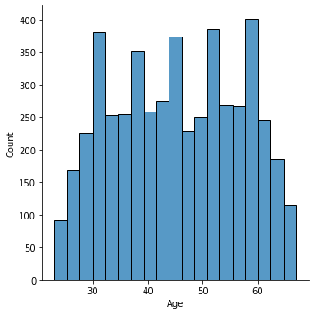

```python
sns.displot(final.Age)
```

#### 3. Data Preparation and model building

##### 3.1 Split data into X and Y.

```python
# Drop ZipCode colums

final.head(5)
```

|  | Age | CustomerSince | HighestSpend | ZipCode | HiddenScore | MonthlyAverageSpend | Level | Mortgage | Security | FixedDepositAccount | InternetBanking | CreditCard | LoanOnCard |
| --- | --- | --- | --- | --- | --- | --- | --- | --- | --- | --- | --- | --- | --- |
| 9 | 34 | 9.0 | 180 | 93023 | 1 | 8.9 | 3 | 0 | 0 | 0 | 0 | 0 | 1.0 |
| 10 | 65 | 39.0 | 105 | 94710 | 4 | 2.4 | 3 | 0 | 0 | 0 | 0 | 0 | 0.0 |
| 11 | 29 | 5.0 | 45 | 90277 | 3 | 0.1 | 2 | 0 | 0 | 0 | 1 | 0 | 0.0 |
| 12 | 48 | 23.0 | 114 | 93106 | 2 | 3.8 | 3 | 0 | 1 | 0 | 0 | 0 | 0.0 |
| 13 | 59 | 32.0 | 40 | 94920 | 4 | 2.5 | 2 | 0 | 0 | 0 | 1 | 0 | 0.0 |

```python
final.drop(['ZipCode'], axis=1, inplace=True)
```

```python
final.head(5)
```

|  | Age | CustomerSince | HighestSpend | HiddenScore | MonthlyAverageSpend | Level | Mortgage | Security | FixedDepositAccount | InternetBanking | CreditCard | LoanOnCard |
| --- | --- | --- | --- | --- | --- | --- | --- | --- | --- | --- | --- | --- |
| 9 | 34 | 9.0 | 180 | 1 | 8.9 | 3 | 0 | 0 | 0 | 0 | 0 | 1.0 |
| 10 | 65 | 39.0 | 105 | 4 | 2.4 | 3 | 0 | 0 | 0 | 0 | 0 | 0.0 |
| 11 | 29 | 5.0 | 45 | 3 | 0.1 | 2 | 0 | 0 | 0 | 1 | 0 | 0.0 |
| 12 | 48 | 23.0 | 114 | 2 | 3.8 | 3 | 0 | 1 | 0 | 0 | 0 | 0.0 |
| 13 | 59 | 32.0 | 40 | 4 | 2.5 | 2 | 0 | 0 | 0 | 1 | 0 | 0.0 |

#### 3. Data Preparation and model building:

##### 3.1 Split data into X and Y

```python
X = final.drop(['LoanOnCard'], axis=1)
```

```python
X.head(3)
```

|  | Age | CustomerSince | HighestSpend | HiddenScore | MonthlyAverageSpend | Level | Mortgage | Security | FixedDepositAccount | InternetBanking | CreditCard |
| --- | --- | --- | --- | --- | --- | --- | --- | --- | --- | --- | --- |
| 9 | 34 | 9.0 | 180 | 1 | 8.9 | 3 | 0 | 0 | 0 | 0 | 0 |
| 10 | 65 | 39.0 | 105 | 4 | 2.4 | 3 | 0 | 0 | 0 | 0 | 0 |
| 11 | 29 | 5.0 | 45 | 3 | 0.1 | 2 | 0 | 0 | 0 | 1 | 0 |

```python
y=final.LoanOnCard
y.head(3)
```

```
9     1.0
10    0.0
11    0.0
Name: LoanOnCard, dtype: category
Categories (2, float64): [0.0, 1.0]
```

```python
X.count()
```

```
Age                    4980
CustomerSince          4980
HighestSpend           4980
HiddenScore            4980
MonthlyAverageSpend    4980
Level                  4980
Mortgage               4980
Security               4980
FixedDepositAccount    4980
InternetBanking        4980
CreditCard             4980
dtype: int64
```

```python
X.info()
```

```
<class 'pandas.core.frame.DataFrame'>
Int64Index: 4980 entries, 9 to 4999
Data columns (total 11 columns):
 #   Column               Non-Null Count  Dtype
---  ------               --------------  -----
 0   Age                  4980 non-null   int64
 1   CustomerSince        4980 non-null   float64
 2   HighestSpend         4980 non-null   int64
 3   HiddenScore          4980 non-null   category
 4   MonthlyAverageSpend  4980 non-null   float64
 5   Level                4980 non-null   category
 6   Mortgage             4980 non-null   int64
 7   Security             4980 non-null   category
 8   FixedDepositAccount  4980 non-null   category
 9   InternetBanking      4980 non-null   category
 10  CreditCard           4980 non-null   category
dtypes: category(6), float64(2), int64(3)
memory usage: 423.3 KB
```

##### 3.2 Split data into train and test. Keep 25% data reserved for testing.

```python
X_train, X_test, y_train, y_test = train_test_split(X, y, test_size=0.25, random_state=10)
```

```python
pd.DataFrame({'X_train': X_train.count(), 'X_test': X_test.count()})
```

|  | X_train | X_test |
| --- | --- | --- |
| Age | 3735 | 1245 |
| CustomerSince | 3735 | 1245 |
| HighestSpend | 3735 | 1245 |
| HiddenScore | 3735 | 1245 |
| MonthlyAverageSpend | 3735 | 1245 |
| Level | 3735 | 1245 |
| Mortgage | 3735 | 1245 |
| Security | 3735 | 1245 |
| FixedDepositAccount | 3735 | 1245 |
| InternetBanking | 3735 | 1245 |
| CreditCard | 3735 | 1245 |

##### 3.3 Train a Supervised Learning Classification base model - Logistic Regression.

```python
from sklearn.linear_model import LogisticRegression
```

```python
logreg = LogisticRegression(solver='lbfgs', max_iter=1000)
```

```python
logreg.fit(X_train, y_train)
```

```
LogisticRegression(max_iter=1000)
```

```python
y_pred = logreg.predict(X_test)
```

```python
print('Accuracy on Training data:',logreg.score(X_train, y_train) )
print('Accuracy on Test data:',logreg.score(X_test, y_test) )
```

```
Accuracy on Training data: 0.9499330655957162
Accuracy on Test data: 0.957429718875502
```